# Homework 6: Prediction II

STA 235H

Due on Nov. 18th, 11:59pm

# Note

- This document will serve as your Answer Key for Homework 6. Please check the rubric to understand how the assignment is graded.
- All automatically-graded questions will receive full credit if correct or 0 points if they are not correct. The only exception is with multiple answers were points are allocated proportionally.
- Inconsistencies between code and answers will be discounted (i.e. if an answer is correct, but the code used to get to that answer is not, that question will be discounted).
- R scripts and PDF files will also be checked for completeness. If they are not complete (i.e. do not contain the code/output requested), a discount will apply.
- After you receive your graded assignment, you will have one week to submit re-grading requests. Please compare your graded submission with this answer key and fill out the re-grading form with your specific request.

# Task 1 - Conceptual Questions

**1.1) Regarding a deeper regression tree compared to a more shallow regression tree, which of the following statements is/are TRUE?:** (4 points)

1. A deeper tree is more precise at prediction than a shallow tree because it is more flexible
2. A deeper tree has a smaller complexity parameter (cp) compared to more shallow tree.
3. On average, a deeper tree has less observations per leaf than a more shallow tree.
4. A deeper tree is more precise at prediction than a shallow tree because it has less bias.

Answer:

B and C

**1.2) Assess whether the following statement is True or False:**

“If $\lambda=0$, a Lasso regression will still have different coefficients than a linear model (lm) with all predictors because Lasso can drop covariates”. (2 points)

Answer:

False

**1.3) Regarding stepwise selection, which of the following statements is/are TRUE? Base your answers on your general knowledge of the method and on this particular output.**

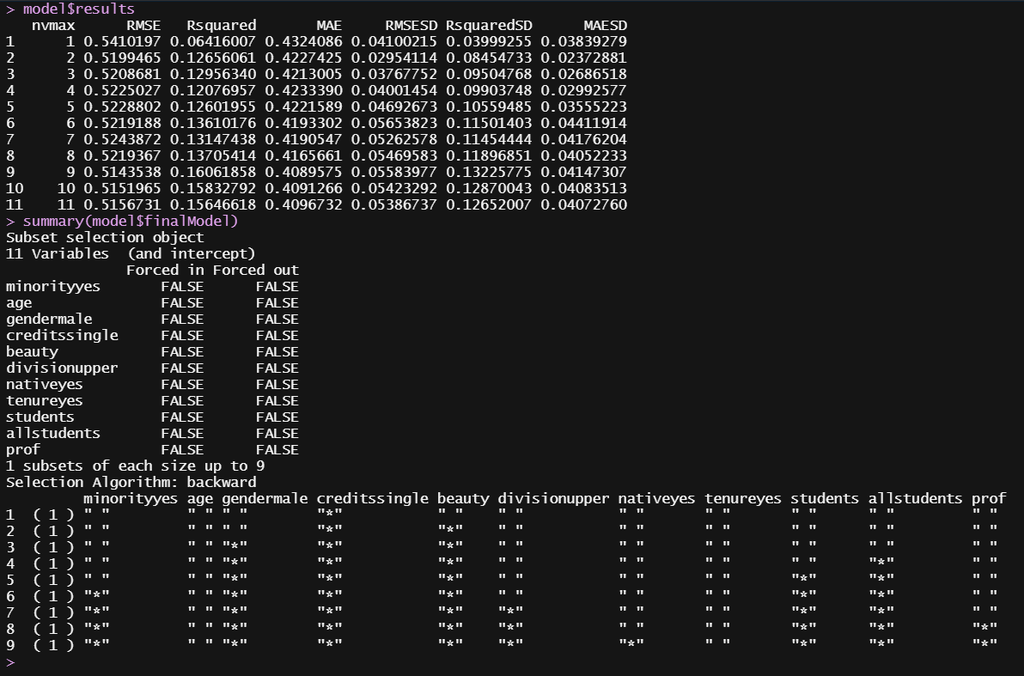

1. Forward and backward stepwise selection can yield different models.
2. Stepwise selection is an efficient way to find the best (optimal) combination of predictors to include in our linear model.
3. The best model, in this case, is the one with two predictors.
4. In this case, we are fitting a backward stepwise selection model.

# Task 2: Approval is everything

In this task, you are working with a simplified version of the Home Mortgage Disclosure Act Data (which we have seen before!), and we are trying to analyze whether there is discrimination in loan decisions.

This is the (abbreviated) data we will be using with data from HMDA:

```r
hmda <- read.csv("https://raw.githubusercontent.com/maibennett/sta235/main/exampleSite/content/Assignments/Homework/HW6/data//hmda_abb.csv")
```

You can find the codebook here

Note: For any cross-validation task, use 10-fold cross-validation, and set a seed of 100. Remember to set a seed before every line of code where you run something random.

**2.1a) Using a balance table (create a separate dataset (d_bal) for this), check the balance between people that got a loan denied vs those that did not. Include your code here and an image of the balance table:** (5 points)

*Note: Only for this question, use a subset of variables: pirat, hirat, mhist, phist, unemp, afam, single, and hschool. Make sure to create dummy variables for categorical variables in your balance dataset (d_bal)!*

Answer:

```r
library(modelsummary)

hmda <- hmda %>% mutate_if(is.character, as.factor)

hmda <- hmda %>% mutate(chist = factor(chist),
                        mhist = factor(mhist))

hmda_bal <- hmda %>% select(deny, pirat, hirat, mhist, phist, unemp, afam, single, hschool) %>%
  mutate(mhist_nolate = ifelse(mhist=="1", 1, 0),
         mhist_nocredit = ifelse(mhist=="2", 1, 0),
         mhist_late_1_2 = ifelse(mhist=="3", 1, 0),
         mhist_more2 = ifelse(mhist=="4", 1, 0),
         phist = as.numeric(phist) - 1,
         afam = as.numeric(afam) - 1,
         single = as.numeric(single) - 1,
         hschool = as.numeric(hschool) - 1) %>% select(-mhist)

datasummary_balance(~ deny, data = hmda_bal, fmt = 3, title = "HMDA Balance Table", dinm_statistic = "p.value")
```

HMDA Balance Table

|  | no (N=2095) Mean | no (N=2095) Std. Dev. | yes (N=285) Mean | yes (N=285) Std. Dev. | Diff. in Means | p |
| --- | --- | --- | --- | --- | --- | --- |
| pirat | 0.323 | 0.079 | 0.389 | 0.216 | 0.066 | <0.001 |
| hirat | 0.251 | 0.071 | 0.290 | 0.200 | 0.040 | 0.001 |
| phist | 0.047 | 0.212 | 0.267 | 0.443 | 0.219 | <0.001 |
| unemp | 3.742 | 1.990 | 4.014 | 2.270 | 0.272 | 0.055 |
| afam | 0.116 | 0.320 | 0.337 | 0.473 | 0.221 | <0.001 |
| single | 0.379 | 0.485 | 0.495 | 0.501 | 0.115 | <0.001 |
| hschool | 0.987 | 0.115 | 0.961 | 0.193 | -0.025 | 0.032 |
| mhist_nolate | 0.331 | 0.471 | 0.186 | 0.390 | -0.145 | <0.001 |
| mhist_nocredit | 0.646 | 0.478 | 0.765 | 0.425 | 0.119 | <0.001 |
| mhist_late_1_2 | 0.015 | 0.123 | 0.032 | 0.175 | 0.016 | 0.129 |
| mhist_more2 | 0.008 | 0.087 | 0.018 | 0.132 | 0.010 | 0.218 |

- 5 points: (i) Selects all pertinent variables, (ii) transforms all categorical variables into dummies, and (iii) creates a balance table for people that got their loan denied and those that did not.
- 3 points: One of the previous items is not correct.
- 1 point: Two of the previous items are not correct.
- 0 points: Any other case.

**2.1b) In a couple of sentences, what can you say about the differences in the profiles of both groups? (Focus on payment-to-income ratio and whether the applicant is African American or not)** (3 points)

Answer:

We can see from the table that people that get denied have a significantly higher payment-to-income ratio compared to the ones that do not get denied. Additionally, African Americans get denied at much higher rates than non-African-American.

- 3 points: Mentions that individuals that have a higher payment to income ratio are more likely to get denied, and that African-Americans get denied at much higher rates that non African-Americans
- 1 point: Doesn’t include one of the previous comparisons.
- 0 points: Any other case.

**2.2a) Let’s start creating prediction methods for loan denial. For this, create the appropriate datasets dividing your data 80% - 20%. Make sure you transform all your categorical variables into factors! Write your code here:** (5 points)

Answer:

```r
# As shown before:
hmda <- hmda %>% mutate_if(is.character, as.factor)

hmda <- hmda %>% mutate(chist = factor(chist),
                        mhist = factor(mhist),
                        deny = as.numeric(deny) - 1)

set.seed(100)

id <- sample(1:nrow(hmda), nrow(hmda)*0.8)

train.data <- hmda %>% slice(id)
test.data <- hmda %>% slice(-id)
```

- 5 points: (i) Transforms all pertinent variables into factors, (ii) sets a seed and (iii) creates a training and testing dataset using a 80%-20% split.
- 3 points: One of the previous items is not correct.
- 1 point: Two of the previous items are not correct.
- 0 points: Any other case.

**2.2b) How many observations does your dataset have?** (1 point)

Answer:

```r
nrow(train.data)
```

```
## [1] 1904
```

**2.3a) First, let’s fit a LPM using a stepwise selection excluding race from the model. Use backward stepswise selection in this case, and show your code here:** (5 points)

*Note: For this model only, run `deny` as a binary variable and ignore a potential warning.*

Answer:

```r
lm_full <- lm(deny ~ . - afam, data = train.data)
nvars <- length(lm_full$coefficients) - 1

train.control <- trainControl(method = "cv", number = 10)

set.seed(100)

bwd.lm <- train(deny ~ . - afam, data = train.data,
                method = "leapBackward",
                tuneGrid = data.frame(nvmax = 1:nvars),
                trControl = train.control)
```

```
## Warning in train.default(x, y, weights = w, ...): You are trying to do
## regression and your outcome only has two possible values Are you trying to do
## classification? If so, use a 2 level factor as your outcome column.
```

- 5 points: (i) Identifies the correct number of predictors (18), (ii) runs a backwards stepwise model with 10-fold cross-validation, (iii) the formula is correct, excluding African American, and (iv) uses the training dataset.
- 3 points: One of the previous items is not correct.
- 1 point: Two of the previous items are not correct.
- 0 points: Any other case.

**2.3b) How many variables does your best model have using the previous method?** (2 points)

Answer:

Our best model has 14 variables.

**2.3c) Is self-employment considered in the previous model?** (2 points)

Answer:

Yes (Check the answer with `summary(bwd.lm$finalModel)`)

**2.4a) Now, let’s run a ridge regression for the previous model your run in 2.3a). Using an interval between 0 and 0.5 (with length 50). Write your code here:** (5 points)

(Remember this is a classification task!)

Answer:

```r
lambda_seq <- seq(0,0.5, length = 50)

set.seed(100)

ridge <- train(factor(deny) ~ . - afam, data = train.data,
                method = "glmnet",
                preProcess = "scale",
                tuneGrid = expand.grid(alpha = 0,
                                       lambda = lambda_seq),
                trControl = train.control)
```

- 5 points: (i) Runs a ridge regression (“glmnet” method with alpha = 0) with 10-fold cross-validation, (ii) deny is a factor variable (to run a classification task), (iii) the formula is correct, excluding African American, (iv) uses the training dataset, (v) sets the correct lambda vector, and (vi) scales their variables.
- 3 points: One of the previous items is not correct.
- 1 point: Two of the previous items are not correct.
- 0 points: Any other case.

**2.4b) What is the optimal regularization parameter found in 2.4a)?** (3 points)

Answer:

```r
round(ridge$bestTune$lambda, 4)
```

```
## [1] 0.0918
```

**2.4c) How does your model perform?** (5 points)

Answer:

```r
pred.values <- ridge %>% predict(test.data)

round(mean(pred.values == test.data$deny), 3)
```

```
## [1] 0.889
```

**2.5a) Now, let’s run a lasso regression for the previous model. Using an interval between 0 and 0.005 (with length 50). Write your code here:** (5 points)

Answer:

```r
lambda_seq <- seq(0,0.005, length = 50)

set.seed(100)

lasso <- train(factor(deny) ~ . - afam, data = train.data,
                method = "glmnet",
               preProcess = "scale",
                tuneGrid = expand.grid(alpha = 1,
                                       lambda = lambda_seq),
                trControl = train.control)
```

- 5 points: (i) Runs a lasso regression (“glmnet” method with alpha = 1) with 10-fold cross-validation, (ii) deny is a factor variable (to run a classification task), (iii) the formula is correct, excluding African American, (iv) uses the training dataset, (v) sets the correct lambda vector, and (vi) scales their variables.
- 3 points: One of the previous items is not correct.
- 1 point: Two of the previous items are not correct.
- 0 points: Any other case.

**2.5b) What is the optimal regularization parameter found in 2.5a)?** (3 points)

Answer:

```r
round(lasso$bestTune$lambda, 4)
```

```
## [1] 0.0004
```

**2.5c) How does your model perform?** (5 points)

Answer:

```r
pred.values <- lasso %>% predict(test.data)

round(mean(pred.values == test.data$deny), 3)
```

```
## [1] 0.899
```

**2.5d) How many variables does your lasso model have?** (3 points)

Answer:

```r
coefs <- coef(lasso$finalModel, lasso$bestTune$lambda)

coefs@p[2] - 1
```

```
## [1] 18
```

**2.6a) Finally, calculate what is the percentage of African American applicants that get their loan approved in our testing dataset.**

Answer:

```r
test.data %>% mutate(afam = as.numeric(afam) - 1) %>% filter(afam==1) %>%
  summarize(mean_approved = 1-mean(deny)) %>% round(., 3)
```

| mean_approved |
| --- |
| 0.714 |

**2.6b) Compare this answer to the predicted values we get using our lasso regression. What is the proportion of African American we predict will get the loan approved in this case?**

Answer:

```r
pred.lasso <- lasso %>% predict(test.data)

test.data <- test.data %>% mutate(pred.denial = as.numeric(pred.lasso)-1)

test.data %>% mutate(afam = as.numeric(afam) - 1) %>% filter(afam == 1) %>%
  summarize(mean_approved_pred = 1 - mean(pred.denial))  %>% round(., 3)
```

| mean_approved_pred |
| --- |
| 0.843 |

Code check for this

# Task 3 - Run, Forest, Run…

In light that Austin is a big football town, in this task we will tackle (pun intended) a prediction problem regarding running yards. With the given dataset, you will need to predict the yardage gained on a specific play given specific characteristics at the time the ball is handed off. You can find a sample of the dataset here:

```r
nfl <- read.csv("https://raw.githubusercontent.com/maibennett/sta235/main/exampleSite/content/Assignments/Homework/HW6/data/nfl.csv")
```

You can find the codebook here

In this case, the outcome of interest is `Yards`. Note that we have three ID variables that we will not use as predictors (`GameId`, `PlayId`, and `NflId`).

For all models, you will need to use a seed 120 and a cross-validation approach with 10 folds. Remember to set a seed before running any line of code that contains any “randomness”.

**3.1) First things first: Drop `Stadium`, `Location`, and `WindDirection`. Also, create a training and a testing dataset with a 90-10 split of your data. How many observations are there in your testing dataset?** (1 point)

Answer:

```r
library(tidyverse)
library(caret)
library(modelr)

nfl <- nfl %>% select(-c(Stadium, Location, WindDirection))

set.seed(120)

id <- sample(1:nrow(nfl), 0.9*nrow(nfl))

train.data <- nfl %>% slice(id)
test.data <- nfl %>% slice(-id)

nrow(test.data)
```

```
## [1] 278
```

We have 278 in our dataset.

**3.2a) For this task, we will create a decision tree. Using the information provided in the introduction of this task, fit a decision tree using tuneLength of 50 to find your best complexity parameter. Include your code here:** (5 points)

Answer:

```r
set.seed(120)

train.control <- trainControl(method = "cv", number = 10)

rt_tl <- train(Yards ~ . - GameId - PlayId - NflId, data = train.data,
            method = "rpart",
            tuneLength = 50,
            trControl = train.control)
```

- 5 points: (i) Runs a decision tree (“rpart”) with 10-fold cross-validation, (ii) Yards is a **not** used as a factor variable, (iii) the formula is correct, excluding the id variables, (iv) uses the training dataset, and (v) sets the correct tuneLength.
- 3 points: One of the previous items is not correct.
- 1 point: Two of the previous items are not correct.
- 0 points: Any other case.

**3.2b) Plot your complexity parameter from the code in 3.2a) (as we have seen in class), and, using only this plot, mention which interval you would use to find a complexity parameter using now tuneGrid. Include a clear image of your plot here.**(5 points)

*No need to write the code for tuneGrid, just mention the interval in words.*

Answer:

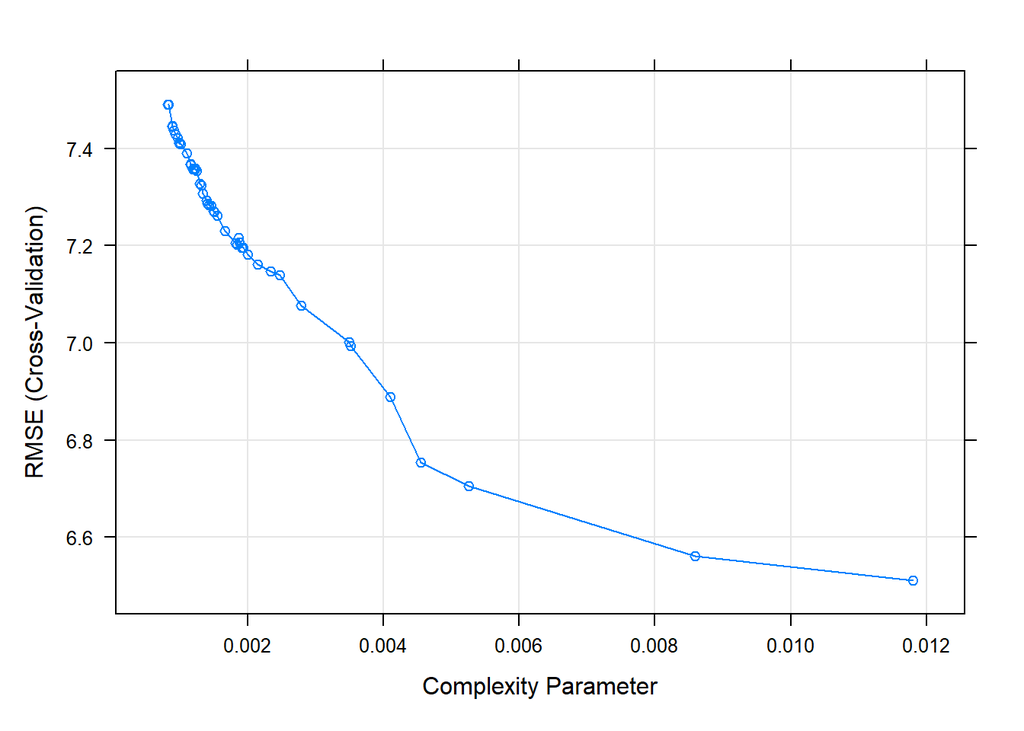

```r
plot(rt_tl)
```

Looking at the plot, I’d choose an interval between 0.01 and 0.014. *(Note: You can also choose another interval close to/around 0.012)*

- 5 points: (i) Shows the correct plot for the previous code and (ii) chooses an interval around the minimum (0.012).
- 2 points: One of the previous items is not correct.
- 0 points: Any other case.

**3.3a) Using the interval you previously described in 3.2b, now use tuneGrid to find the best complexity parameter (use a length of 50 for this). Include your code here:** (5 points)

Answer:

```r
set.seed(120)

rt_tg <- train(Yards ~ . - GameId - PlayId - NflId, data = train.data,
            method = "rpart",
            tuneGrid = expand.grid(cp = seq(0.01, 0.014, length = 50)),
            trControl = train.control)

rt_tg$bestTune$cp
```

```
## [1] 0.01097959
```

- 5 points: (i) Runs a decision tree (“rpart”) with 10-fold cross-validation, (ii) Yards is a **not** used as a factor variable, (iii) the formula is correct, excluding the id variables, (iv) uses the training dataset, and (v) sets the correct tuneGrid (it is fine if it’s not correct, as long as it is consistent with the previous answer).
- 3 points: One of the previous items is not correct.
- 1 point: Two of the previous items are not correct.
- 0 points: Any other case.

**3.3b) What is your best complexity parameter in this case?** *Round your answer to 4 decimal places.* (3 points)

The best complexity parameter in this case is 0.011 (Note: You can have a slightly different answer depending on the interval you proposed before)

**3.3c) How does your model perform? Include the results for the appropriate measure** (3 points)

Answer:

```r
rmse(rt_tg, test.data)
```

```
## [1] 6.185308
```

**3.4) You are not convinced with the previous results, and want to try a new tuneGrid, setting `cp=0` (Hint, you can do this just by replacing cp = 0 instead of cp = seq(…)). What is the most predictive variable in this case?**

*Use the name of the variable in the dataset*

Answer:

```r
set.seed(120)

rt0 <- train(Yards ~ . - GameId - PlayId - NflId, data = train.data,
            method = "rpart",
            tuneGrid = expand.grid(cp = 0),
            trControl = train.control)

rt0$finalModel
```

[output not shown]

The most predictive variable, which is at the top of the tree, is `YardLine`

**3.5) Thinking about the best model you predicted, and looking at the average outcome (you will need to calculate this). Do you think your model has a good performance or not? Why do you think that is? (Give the main reason).** (5 points)

Answer:

In this case, our best model had a RMSE of 6.19 and the average yards in our data is 4.44. Looking at both metrics, it is clear that our best performance model is not very good, where the RMSE is 139.5% of the mean of our outcome. The main reason for this is that single regression trees are high variance models, tend to overfit our data, and don’t provide robust results.

- 5 points: (i) Calculates the average outcome correctly (this can be in the testing dataset or the entire dataset, numbers are going to be similar), (ii) compares this number to the RMSE of the best model, (iii) says the model is not very good, and (iv) talks about disadvantages of single decision trees (high-variance/overfit data)
- 3 points: One of the previous items is not correct.
- 1 point: Two of the previous items are not correct.
- 0 points: Any other case.